# Acesso Aberto aos Dados da Pesquisa em Ciência do Solo

2020-10-05

## Quantos pontos a figura contém?

- Os pontos ao lado representam locais de amostragem do solo
  - São locais para onde temos *dados abertos do solo*

Registre sua estimativa em  
www.pedometria.org/projeto/febr/

O sócio da SBCS cuja estimativa chegar mais perto do número correto receberá um prêmio pedológico!

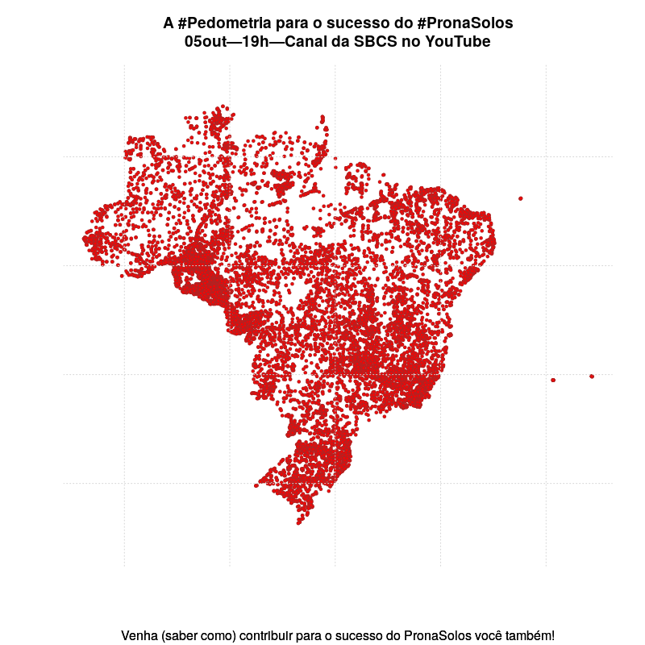

[interactive chart not shown]

## Um pouco de história

## 2020–2050

[figure not shown]

> Pelos próximos 30 anos, o PronaSolos envolverá dezenas de instituições parceiras, dedicadas à investigação, documentação, inventário e interpretação dos *dados de solos* brasileiros. O objetivo é mapear os solos de 1,3 milhão de km² do País nos primeiros dez anos, e mais 6,9 milhões de km² até 2048, em escalas que vão de 1:25.000 a 1:100.000.

## 1970–1985

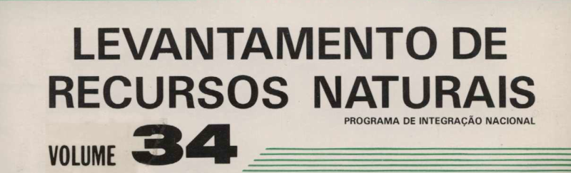

> O projeto RADAM - Radar na Amazônia – foi criado em 1970, priorizando a coleta de *dados* sobre recursos minerais, solos, vegetação, uso da terra e cartografia da Amazônia e áreas adjacentes da região Nordeste. Em 1975, o levantamento foi expandido para o restante do território nacional, visando o mapeamento integrado dos recursos naturais e passando a ser denominado Projeto RADAMBRASIL.

## E antes disso… na Rússia e EUA

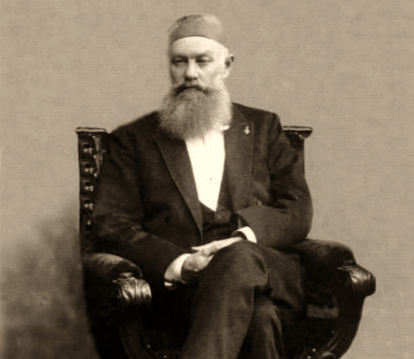

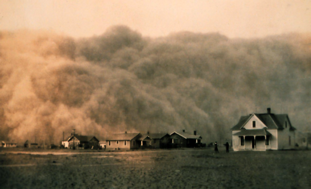

## O que foi que mudou desde então?

[figure not shown]

## 1985–2015 (ferramentas)

**Pedometria**

- 1985–2000
  - computadores
  - Internet
  - (geo)estatística
  - sensoriamento remoto
  - sistemas de informação geográfica

**Mapeamento digital do solo**

- 2000–2015
  - sensoriamento proximal
  - bancos de dados
  - computação de alto desempenho
  - aprendizado de máquina
  - programação em R e Python

## 1985–2015 (procedimentos)

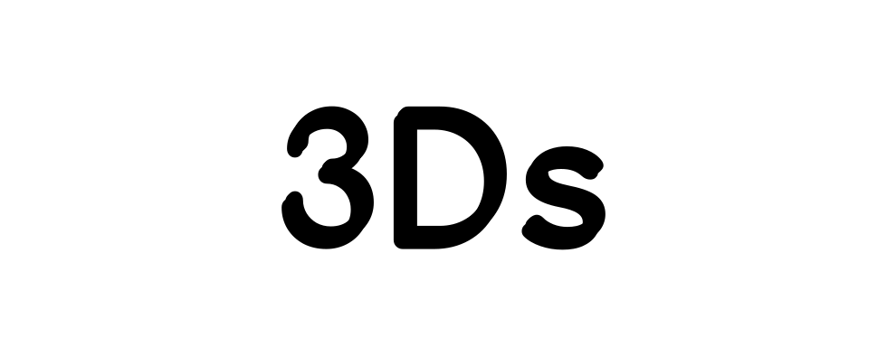

## Digitalização

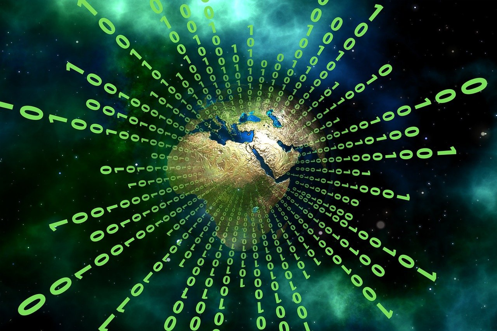

## Decentralização

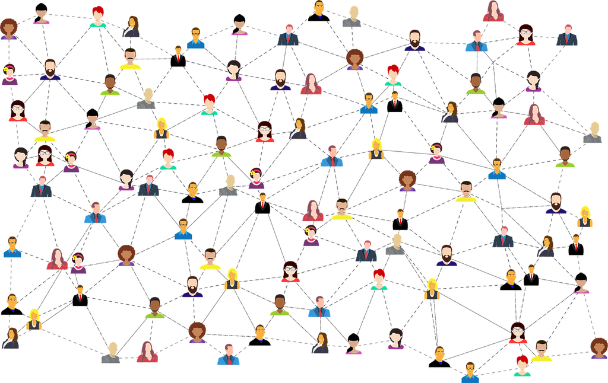

## Diversificação

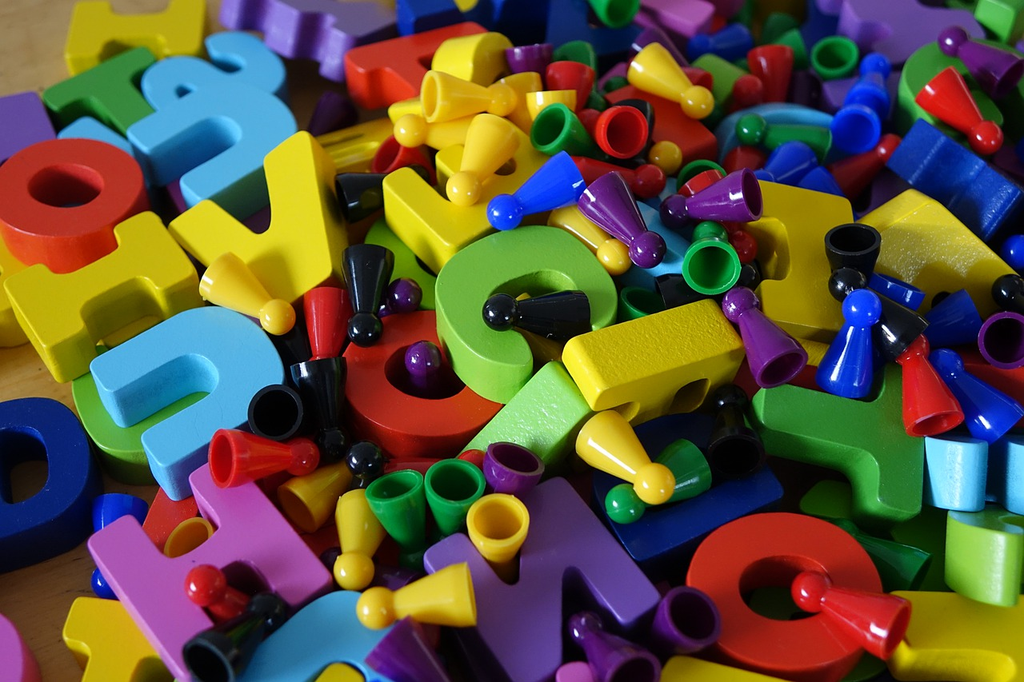

## 1985–2015 (dados do solo)

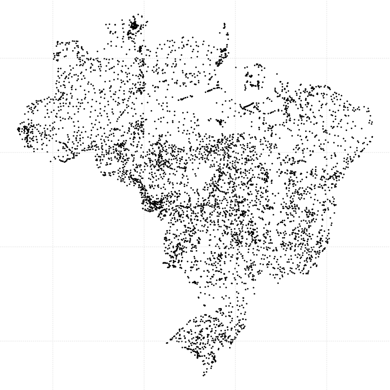

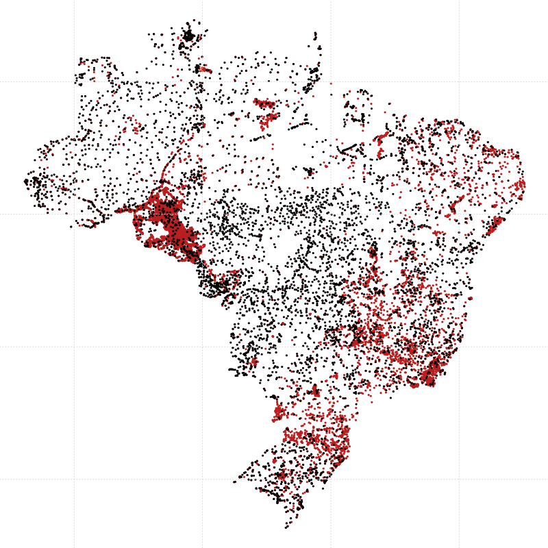

## O que são dados abertos?

[figure not shown]

## As três leis dos dados abertos

1. Encontrados na Internet
   - Do contrário, é como se os dados não existissem
   - “Os dados estão disponíveis mediante contato com os autores.”

## As três leis dos dados abertos

1. Encontrados na Internet
   - Do contrário, é como se os dados não existissem
   - “Os dados estão disponíveis mediante contato com os autores.”
2. Formato que permita imediata leitura e manipulação em software
   - Do contrário, os dados não são dados… são texto ou imagem
   - “Os dados estão disponíveis no apêndice da tese.”

## As três leis dos dados abertos

1. Encontrados na Internet
   - Do contrário, é como se os dados não existissem
   - “Os dados estão disponíveis mediante contato com os autores.”
2. Formato que permita imediata leitura e manipulação em software
   - Do contrário, os dados não são dados… são texto ou imagem
   - “Os dados estão disponíveis no apêndice da tese.”
3. Livres de impedimentos legais ao reúso e redistribuição
   - Do contrário, os dados são inúteis
   - “Licença Creative Commons Atribuição-NãoComercial-CompartilhaIgual”

## Oito princípios básicos

1. **Completos:** todos os dados serem publicizados, não apenas uma parte deles
2. **Primários:** como na fonte, não uma versão agregada ou transformada
3. **Atuais:** publicados o mais rápido o possível para garantir seu valor
4. **Acessíveis:** disponibilizados ao maior público para a maior variedade de usos
5. **Processáveis por máquina:** estrutura que não exige intervenção manual
6. **Acesso não discriminatório:** disponíveis à todos, sem exigir identificação
7. **Formato não proprietário:** fora do controle de empresa ou organização
8. **Livre de licenças:** sem regulações de direitos autorais ou segredo industrial

## References

Ditzler, C. A., and R. J. Ahrens. 2006. “Development of Soil Taxonomy in the United States of America.” *Eurasian Soil Science* 39 (2): 141–46. https://doi.org/10.1134/S1064229306020049.